# Stage 06 — Exploratory Data Analysis

Hemanth Sai Charagundla

# 1. Purpose

This stage performs exploratory data analysis on the feature-enhanced CPC18 dataset.

The analysis examines decision behavior, expected payoff and probability differences, experimental conditions, temporal patterns, relationships among engineered features, and reaction-time data.

The purpose is to identify descriptive patterns that can guide the formal statistical analysis in Stage 07.

# 2. Prerequisites and Execution Order

Stage 06 depends on the validated and feature-enhanced CPC18 dataset.

The required execution order is:

1. `R/01_data_loading.R` — load the CPC18 raw dataset.
2. `R/03_data_cleaning.R` — create the cleaned analytical dataset.
3. `R/04_data_validation.R` — validate logical and structural consistency.
4. `R/05_feature_engineering.R` — construct mathematically meaningful decision features.
5. `R/06_eda.R` — perform exploratory analysis.
6. `reports/06_eda.Rmd` — document the exploratory findings.

The project root is explicitly set as the working directory before the pipeline scripts are sourced.

# 3. Load Required Packages

# 4. Run Exploratory Analysis

The Stage 06 analysis is implemented in `R/06_eda.R`.

The script generates the EDA summaries and visualizations used in this report. Plots are also saved as PNG files in `outputs/eda/`.

# 5. Decision Behavior

The overall choice distribution establishes the baseline proportion of A and B selections.

[output not shown]

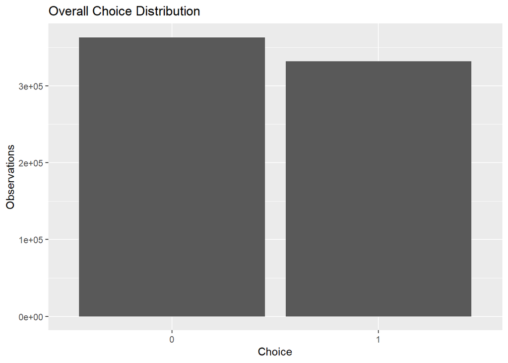

Choice behavior is then examined across differences in expected payoff and probability between options A and B.

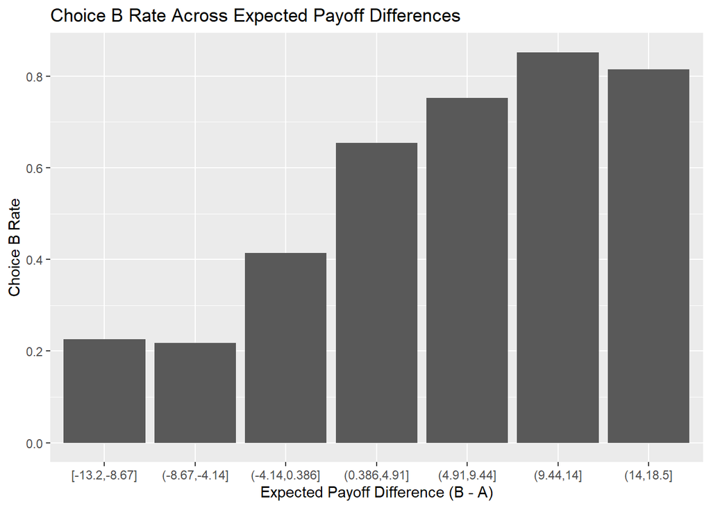

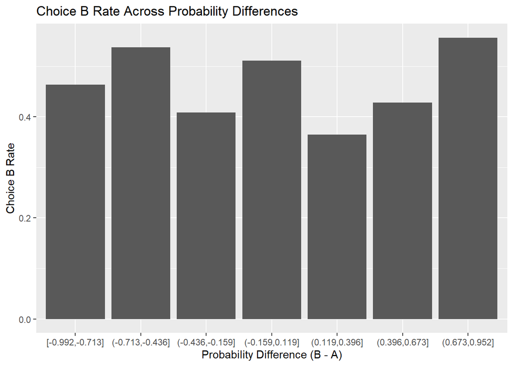

These plots provide descriptive evidence about how relative decision attributes correspond to observed choice behavior.

# 6. Experimental and Temporal Conditions

Choice behavior is explored across ambiguity and feedback conditions.

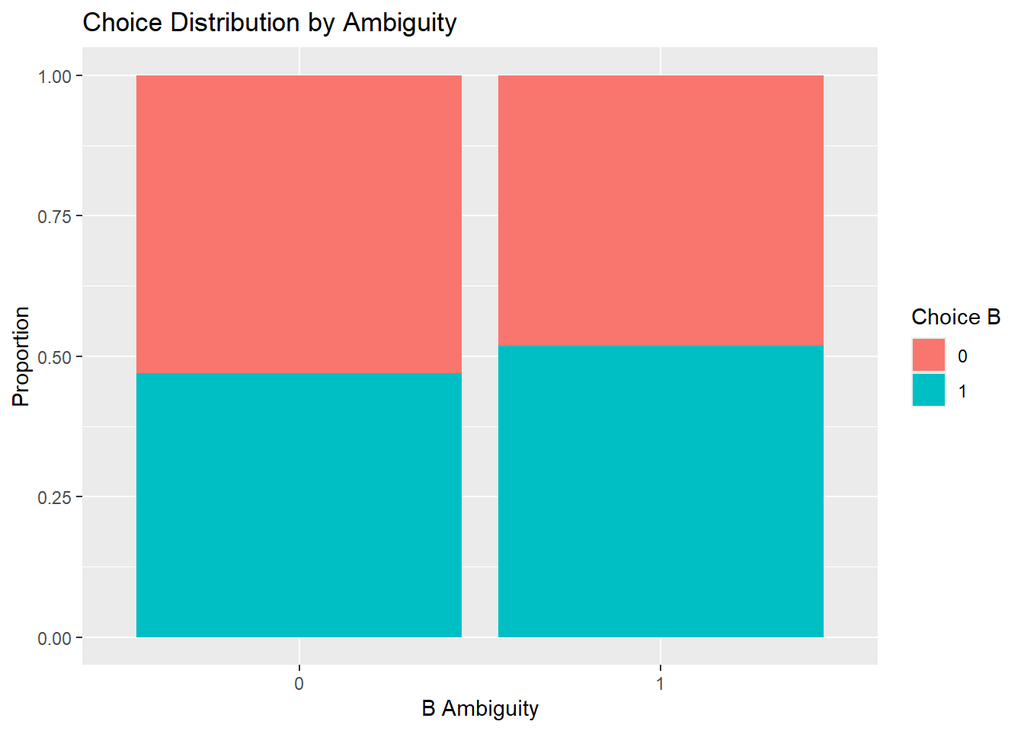

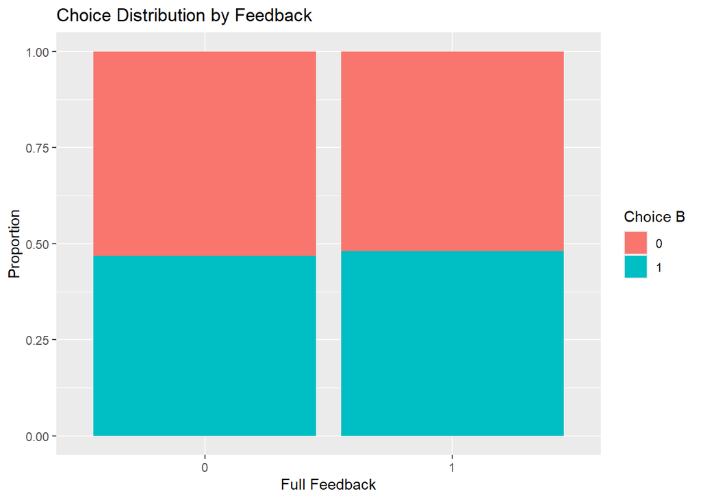

Temporal patterns are examined across time blocks and game order.

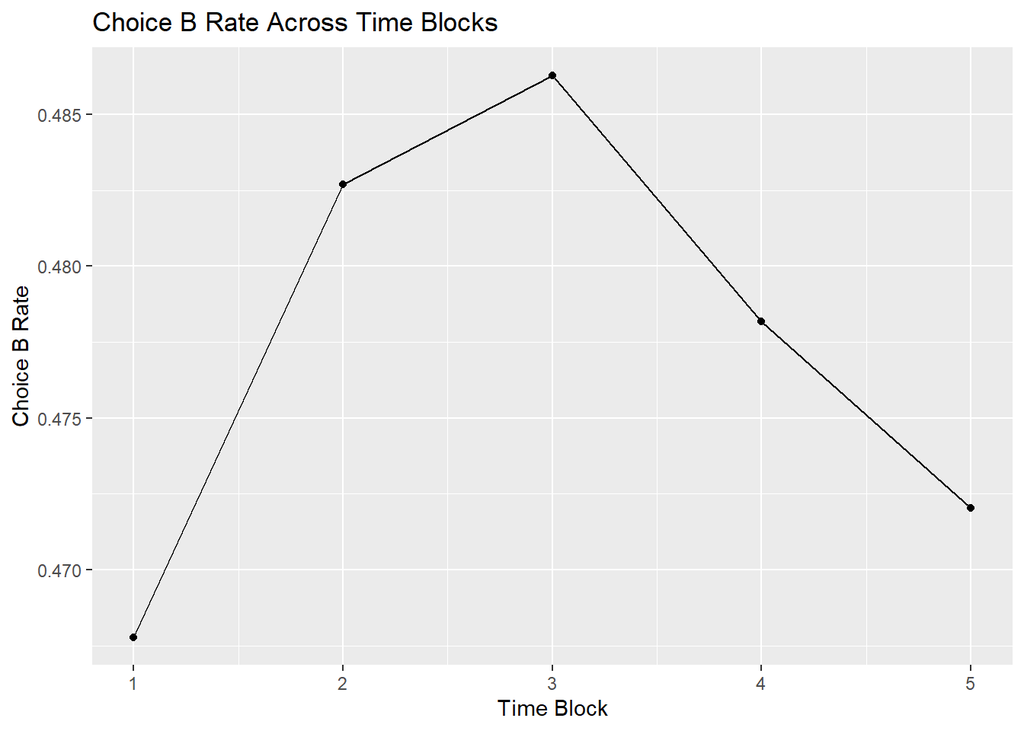

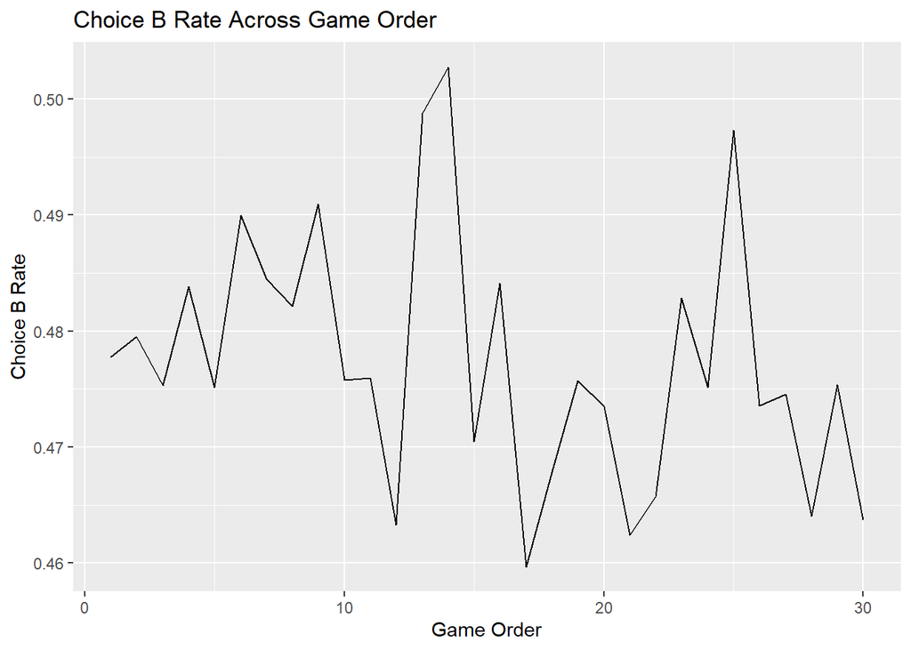

These analyses are descriptive and are used to identify relationships that may require formal testing.

# 7. Feature Relationships

The engineered numerical variables are examined through pairwise correlations to identify strongly related predictors and potential redundancy before statistical modelling and machine learning.

|  | expected_payoff_a | expected_payoff_b | expected_payoff_diff | absolute_expected_payoff_diff | probability_diff | absolute_probability_diff | low_payoff_diff | high_lottery_ev_diff | payoff_spread_a | payoff_spread_b | payoff_spread_diff | lottery_outcomes_diff |
| --- | --- | --- | --- | --- | --- | --- | --- | --- | --- | --- | --- | --- |
| expected_payoff_a | 1.00 | 0.92 | -0.21 | 0.04 | 0.09 | -0.05 | -0.02 | 0.00 | 0.08 | 0.08 | 0.01 | -0.05 |
| expected_payoff_b | 0.92 | 1.00 | 0.20 | 0.09 | 0.08 | -0.05 | 0.04 | 0.05 | 0.07 | 0.08 | 0.02 | -0.02 |
| expected_payoff_diff | -0.21 | 0.20 | 1.00 | 0.12 | -0.01 | 0.00 | 0.14 | 0.11 | -0.04 | 0.01 | 0.03 | 0.07 |
| absolute_expected_payoff_diff | 0.04 | 0.09 | 0.12 | 1.00 | -0.08 | 0.09 | 0.02 | 0.05 | 0.06 | 0.09 | 0.04 | -0.10 |
| probability_diff | 0.09 | 0.08 | -0.01 | -0.08 | 1.00 | -0.55 | -0.01 | -0.62 | 0.50 | -0.23 | -0.50 | -0.09 |
| absolute_probability_diff | -0.05 | -0.05 | 0.00 | 0.09 | -0.55 | 1.00 | 0.08 | 0.29 | -0.13 | 0.15 | 0.20 | -0.01 |
| low_payoff_diff | -0.02 | 0.04 | 0.14 | 0.02 | -0.01 | 0.08 | 1.00 | -0.30 | 0.42 | -0.49 | -0.64 | 0.00 |
| high_lottery_ev_diff | 0.00 | 0.05 | 0.11 | 0.05 | -0.62 | 0.29 | -0.30 | 1.00 | -0.58 | 0.73 | 0.93 | 0.06 |
| payoff_spread_a | 0.08 | 0.07 | -0.04 | 0.06 | 0.50 | -0.13 | 0.42 | -0.58 | 1.00 | -0.01 | -0.63 | -0.18 |
| payoff_spread_b | 0.08 | 0.08 | 0.01 | 0.09 | -0.23 | 0.15 | -0.49 | 0.73 | -0.01 | 1.00 | 0.78 | -0.09 |
| payoff_spread_diff | 0.01 | 0.02 | 0.03 | 0.04 | -0.50 | 0.20 | -0.64 | 0.93 | -0.63 | 0.78 | 1.00 | 0.05 |
| lottery_outcomes_diff | -0.05 | -0.02 | 0.07 | -0.10 | -0.09 | -0.01 | 0.00 | 0.06 | -0.18 | -0.09 | 0.05 | 1.00 |

Correlation is treated as a descriptive measure and not as evidence of causation.

# 8. Reaction-Time Exploration

Reaction-time data are explored separately because RT is unavailable for a substantial portion of the dataset.

The analysis summarizes RT availability and examines the distribution of positive RT observations.

| observations | available | unavailable | availability_rate | zero_rt | median_rt | mean_rt | p95_rt | p99_rt | maximum_rt |
| --- | --- | --- | --- | --- | --- | --- | --- | --- | --- |
| 694500 | 360000 | 334500 | 0.52 | 27 | 657 | 1348.96 | 3734 | 15010 | 395084 |

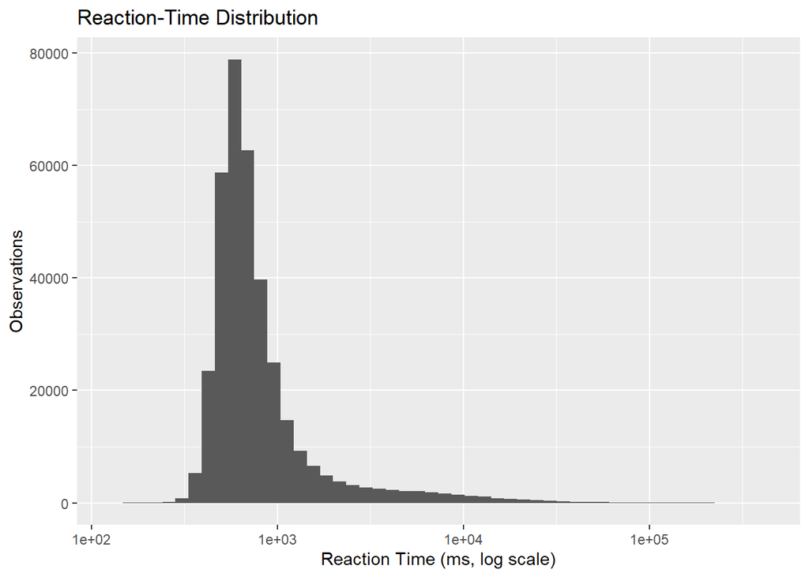

The logarithmic x-axis is used to make the spread of reaction times easier to inspect.

# 9. EDA Summary

Stage 06 establishes the main descriptive patterns in the CPC18 decision data.

The observed relationships between decision attributes, experimental conditions, temporal variables, and choice behavior provide the basis for defining the formal statistical questions addressed in Stage 07.

No formal hypothesis-testing conclusions or causal interpretations are made at this stage.